# LinearRegression

## Question: Why would we want to convert x and y points from int values to floats?

```python
# so they are easy to manipulate and take the mean of when finding m and b
```

```python
import numpy as np
def calculate_regression(points): # input is the result of np.argwhere
    points = points.astype(float)
    xs = points[:,0] # slice along the vertical columns
    ys = points[:,1]
    x_mean = np.mean(xs)
    y_mean = np.mean(ys)

    xy_mean = np.mean(xs*ys)

    x_squared_mean = np.mean(xs**2)

    m = (x_mean * y_mean - xy_mean)/(x_mean**2 - x_squared_mean)

    b = y_mean - m*x_mean

    return (m,b)
    #cv.morphopen
```

```python
import numpy as np
a = np.array([[ 0.14022471,  0.96360618],  #random
       [ 0.37601032,  0.25528411],  #random
       [ 0.49313049,  0.94909878]]) #random
print(a.shape)
```

```
(3, 2)
```

The intercept we calculated, $b$, may be outside of the pixel space of the image, so we must find two points inside of pixel space, $(x_1, y_1)$ and $(x2, y2)$ which will allow us to plot our regression line on the image. It may be best to choose points on the regression line which also occur on the boundaries/extrema of the image.

```python
def find_inliers(m, b, shape):
    # find intersection of the box
    y = float(shape[0])
    x = float(shape[1])
    xs=[0,shape[0],-b/m,(shape[1]-b)/m]

    if m != 0:
        xs.sort()
        x_1=xs[1]
        x_2=xs[2]
        y_1=m*x_1+b
        y_2=m*x_2+b
        return([x_1,x_2],[y_1,y_2])

m,b = calculate_regression(np.argwhere(star))
print (m,b)
_ = find_inliers(m,b, star.shape)
print(find_inliers(m,b, star.shape))
```

[output not shown]

```
(146, 125)
```

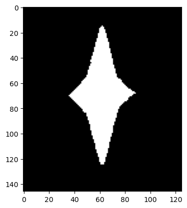

```python
import cv2
star = cv2.imread('shapes/squishedstar.png', cv2.IMREAD_GRAYSCALE)
print(star.shape)

_, star = cv2.threshold(star,125,255,cv2.THRESH_BINARY)
fig,ax = plt.subplots()
ax.imshow(star, cmap='gray');
```

```
(146, 125)
```

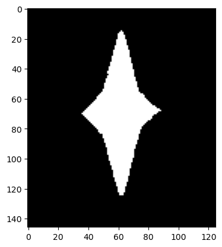

```python
import cv2
star = cv2.imread('shapes/squishedstar.png', cv2.IMREAD_GRAYSCALE)
print(star.shape)

_, star = cv2.threshold(star,125,255,cv2.THRESH_BINARY)
fig,ax = plt.subplots()
ax.imshow(star, cmap='gray');
```

```python
m,b = calculate_regression(np.argwhere(star))
_ = find_inliers(m,b, star.shape)
```

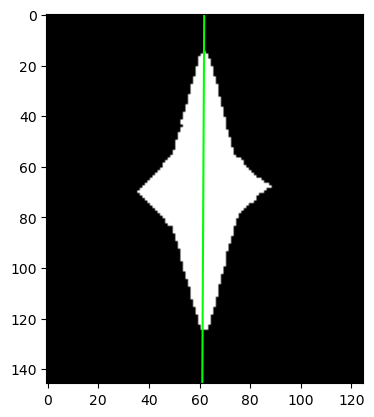

```python
# below is an example of how to draw a random line from (10,25) to (10,55)
# TODO: replace this with the result of find_inliers
# -- pay attention to the directions of the x and y axes
#    in image space, row-column space, and cartesian space
# Look at the help function for Line2D below
#((None, 146.0), (125.0, 66.81778197976166), (None, 0), (59.67952066173313, 0))
fig,ax = plt.subplots()
ax.imshow(star, cmap='gray');
mask=np.argwhere(star)
m,b=calculate_regression(mask)
pts=find_inliers(m,b, star.shape)
regression = Line2D(pts[1],pts[0],color='lime')
ax.add_line(regression);
```

```python
Line2D?
```

[output not shown]

[output cut: 29 more lines]

[output not shown]

## TODO

1. Run your linear regression algorithm on the following images.
2. Plot each of the results.
3. Include each result in your submitted PDF.

[figure not shown]

```python
lightningbolt      = cv2.imread('shapes/lightningbolt.png', cv2.IMREAD_GRAYSCALE)

fig,ax = plt.subplots()
ax.imshow(lightningbolt, cmap='gray');
mask=np.argwhere(lightningbolt)
m,b=calculate_regression(mask)
pts=find_inliers(m,b, lightningbolt.shape)
regression = Line2D(pts[1],pts[0],color='lime')
ax.add_line(regression);
```

[output not shown]

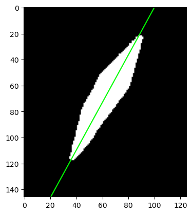

```python
blob               = cv2.imread('shapes/blob.png', cv2.IMREAD_GRAYSCALE)
_, blob = cv2.threshold(blob,125,255,cv2.THRESH_BINARY)
fig,ax = plt.subplots()
ax.imshow(blob, cmap='gray');
mask=np.argwhere(blob)
m,b=calculate_regression(mask)
pts=find_inliers(m,b, blob.shape)
regression = Line2D(pts[1],pts[0],color='lime')
ax.add_line(regression);

images = [lightningbolt, blob, star, squishedstar, squishedturnedstar, letterj]
```

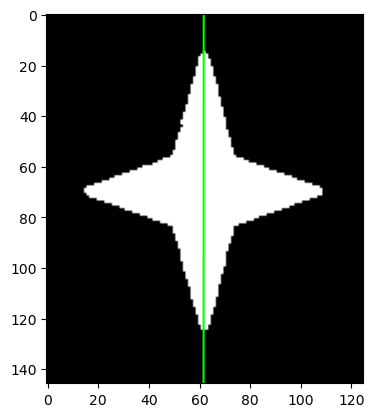

```python
star               = cv2.imread('shapes/star.png', cv2.IMREAD_GRAYSCALE)

_, star = cv2.threshold(star,125,255,cv2.THRESH_BINARY)
fig,ax = plt.subplots()
ax.imshow(star, cmap='gray');
mask=np.argwhere(star)
m,b=calculate_regression(mask)
pts=find_inliers(m,b, star.shape)
regression = Line2D(pts[1],pts[0],color='lime')
ax.add_line(regression);
```

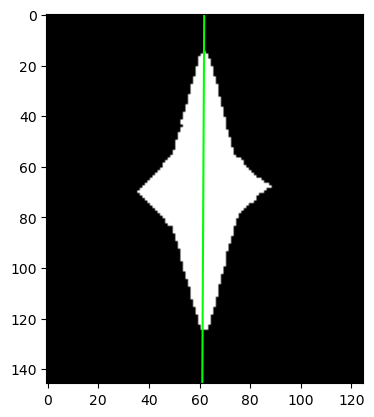

```python
squishedstar       = cv2.imread('shapes/squishedstar.png', cv2.IMREAD_GRAYSCALE)
_, squishedstar = cv2.threshold(squishedstar,125,255,cv2.THRESH_BINARY)
fig,ax = plt.subplots()
ax.imshow(squishedstar, cmap='gray');
mask=np.argwhere(squishedstar)
m,b=calculate_regression(mask)
pts=find_inliers(m,b, squishedstar.shape)
regression = Line2D(pts[1],pts[0],color='lime')
ax.add_line(regression);
```

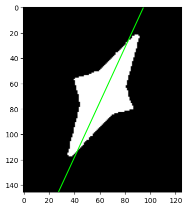

```python
import cv2
squishedturnedstar = cv2.imread('shapes/squishedturnedstar.png', cv2.IMREAD_GRAYSCALE)
_, squishedturnedstar = cv2.threshold(squishedturnedstar,125,255,cv2.THRESH_BINARY)
fig,ax = plt.subplots()
ax.imshow(squishedturnedstar, cmap='gray');
mask=np.argwhere(squishedturnedstar)
m,b=calculate_regression(mask)
pts=find_inliers(m,b, squishedturnedstar.shape)
regression = Line2D(pts[1],pts[0],color='lime')
ax.add_line(regression);
```

```python
_, squishedturnedstar = cv2.threshold(squishedturnedstar,125,255,cv2.THRESH_BINARY)
fig,ax = plt.subplots()
ax.imshow(squishedturnedstar, cmap='gray');
mask=np.argwhere(squishedturnedstar)
m,b=calculate_regression(mask)
pts=find_inliers(m,b, squishedturnedstar.shape)
regression = Line2D(pts[1],pts[0],color='lime')
ax.add_line(regression);
images = [lightningbolt, blob, star, squishedstar, squishedturnedstar, letterj]
```

[output not shown]

## When you are done:

1. Double-check that you filled in your name at the top of the notebook!
2. Click `File` -> `Export Notebook As` -> `PDF`
3. Email the PDF to `YOURTEAMNAME@beaver.works`

## Stretch goal

*Implement a machine learning algorithm!*

**Ran**dom **Sa**mple **C**onsensus, commonly referred to as *RANSAC*, is one of the most widely used machine learning algorithms. In essence, it is a 'guess and check' algorithm. Take a small random sample of your data - two points in this case. Next, define a line through those two points. After doing so, count the number of *inliers*, or points closest to that line (euclidean distance is one way to do this).

https://en.wikipedia.org/wiki/Random_sample_consensus

Implement RANSAC for linear regression, and run it on all of your images.